# ANCOVA moderation tutorial

Matt Minich

2024-11-18

## Gryffin’s ANCOVA

This document is meant to help me (Matt) understand the process of testing a statistical question that informs [REDACTED]’s dissertation. He’s conducted a survey experiment to explore how differences between individuals and aspects of news coverage shape people’s opinions of protesters.

One of the relationships he expects to see in his data is:

Controlling for any effects of his experimental manipulation (assignment to one of two news framing conditions), opinions about protesters will be informed by an interaction between participants’ *party affiliation* and their *hostile media perceptions*. Specifically, he expects that hostile media perceptions will have a stronger negative effect on their positions about protesters for among Republican participants than Democratic participants.

Just because I’ve never seen this data before, I’ll date a quick look at it.

```r
mean(df$position) # 5.966
```

```
## [1] 5.966398
```

```r
sd(df$position) # 3.668
```

```
## [1] 3.668475
```

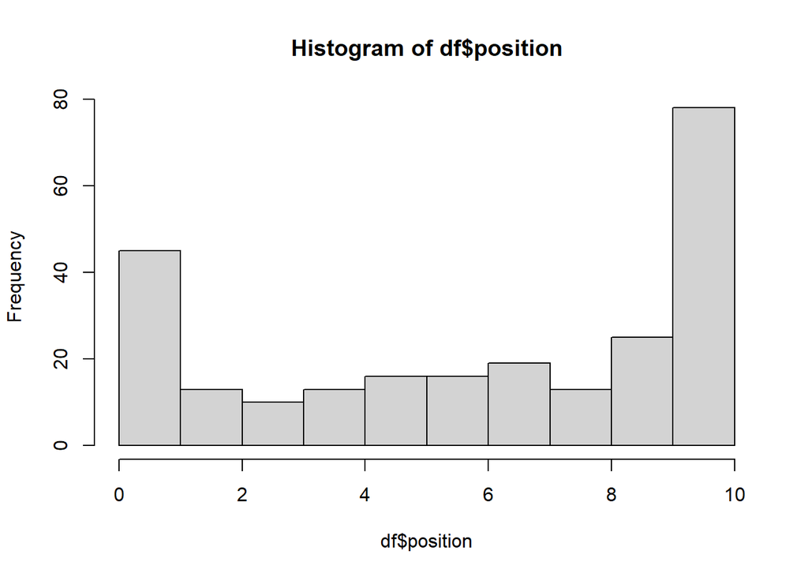

```r
hist(df$position)
```

The outcome has a mean of 5.966 and an sd of 3.668. The distribution of outcomes is bimodal and left-skewed (this isn’t a problem — linear regression doesn’t make any assumptions about the distribution of the outcome).

```r
table(df$condition)
```

```
##
## high W  low W
##    123    125
```

```r
df$condition_num<- ifelse(df$condition == 'high W', 1, 0) # Just making this numeric because it makes it easier to plot later
```

Of the n = 248 participants, they are almost evenly split across the two experimental conditions. This is great!

```r
table(df$party)
```

```
##
##   Democrat Republican
##        125        123
```

```r
df$party_num <- ifelse(df$party == 'Republican', 1, 0)
```

Participants are also almost evenly split between Democrats and Republicans. This is nice!

Just for kicks, let’s see if there are any big differences in the number of participants in each cell of the 2x2 matrix that exists for these conditions

```r
table(df$party,df$condition)
```

```
##
##              high W low W
##   Democrat       63    62
##   Republican     60    63
```

Looks good to me :).

```r
mean(df$hmp) # 4.077
```

```
## [1] 4.076613
```

```r
sd(df$hmp) # 2.779
```

```
## [1] 2.779002
```

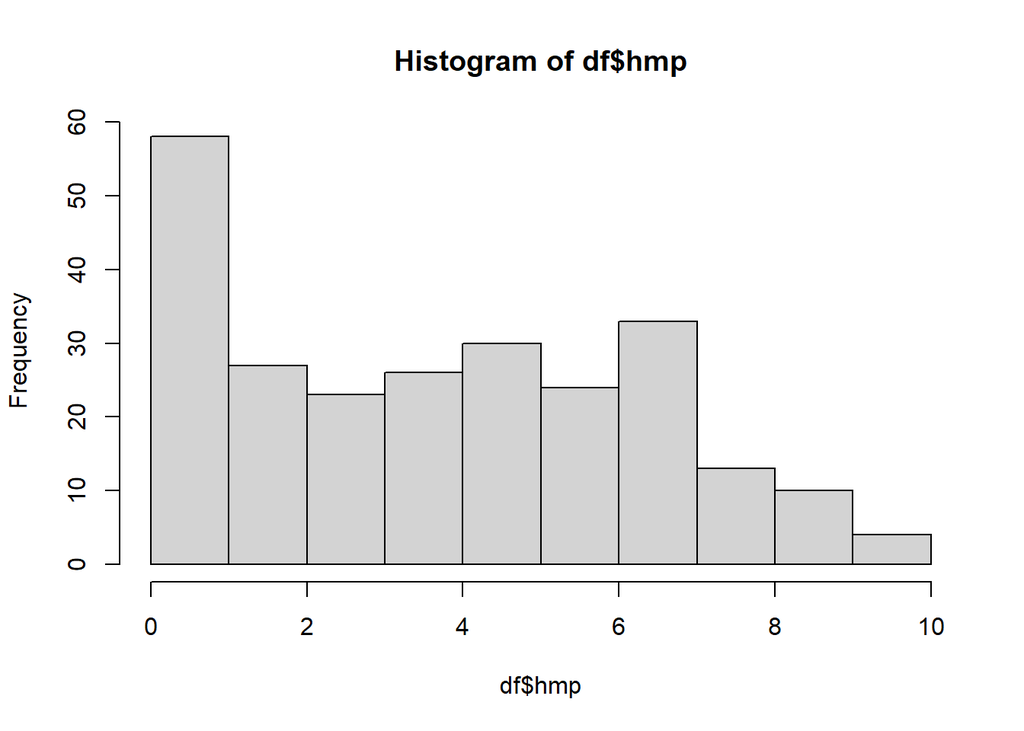

```r
hist(df$hmp)
```

```r
df$hmp_C <- df$hmp - mean(df$hmp) # Just centering this for ease of interpretation later
```

Hostile media perceptions have a right-skewed distribution, with participants tending to report lower perceptions. Regression doesn’t make any assumptions about the distribution of predictors, but it’s good to know.

So!

We have a continuous outcome (position on protesters), a categorical covariate (condition), a categorical predictor (party), a continuous predictor (hostile media perceptions), and an interaction term that describes the relationship between party and hostile media perceptions in predicting position on protesters.

We’ll test this with a regression model:

```r
model <- lm(position ~ condition_num + party_num*hmp_C, df)
```

## Testing assumptions

Before checking the results, we’ll make sure the data meets the assumptions made by linear regression models.

### 1. Exact X.

We assume that both “condition” and “party” are perfect measures, but assume there is some acceptable degree of measurement error for hmp.

### 2. Independence.

This is really a design question. I assume that these participants aren’t clustered together in any really meaningful way that wasn’t measured.

### 3. Normality.

We assume that the residuals have a normal distribution (or close to it)

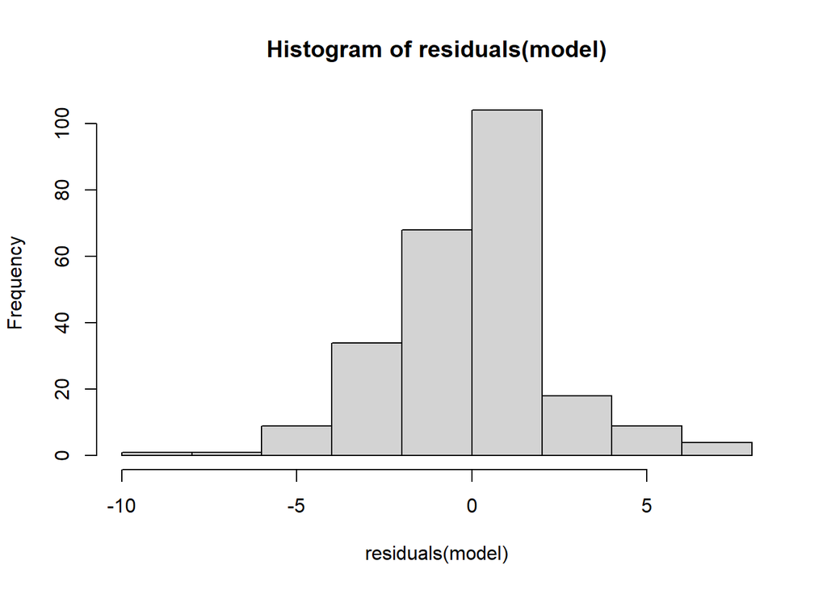

```r
hist(residuals(model))
```

Looks pretty good just using a histogram. But let’s try a QQ plot too.

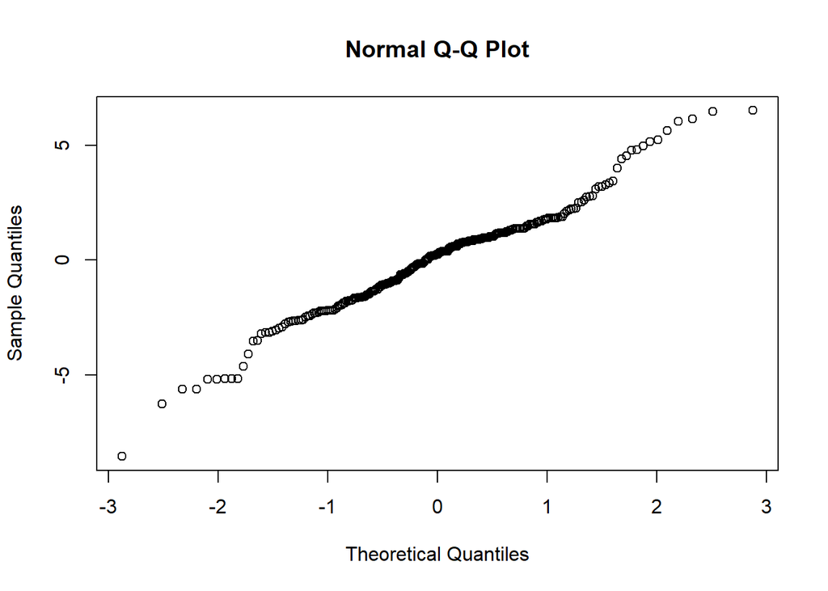

```r
qqnorm(residuals(model))
```

Looks good to me :)

### 4. Constant variance

We need to confirm that the residuals don’t vary as a factor of any of our predictor variables (that our model predictions are not more off for Republicans than Democrats, for example)

First, we’ll just plot the residuals against the values that would be predicted by the model (the “fitted values”)

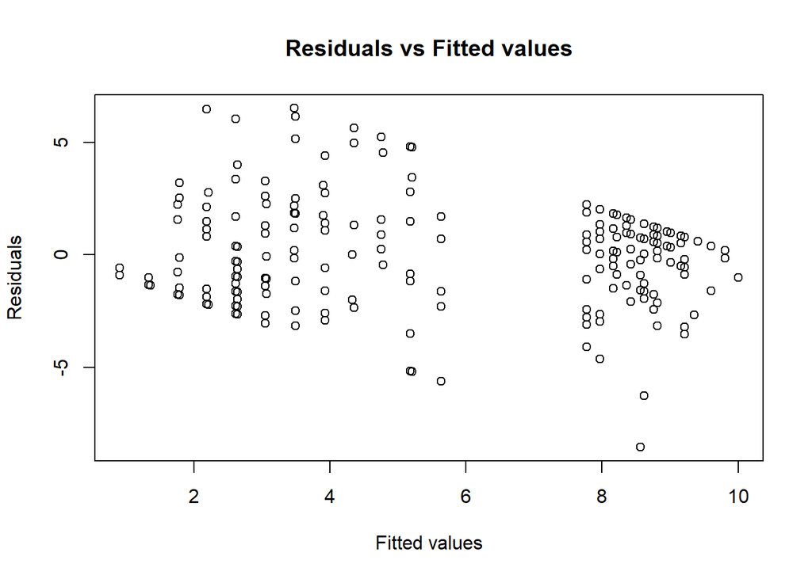

```r
plot(fitted(model),residuals(model),
     xlab = 'Fitted values',
     ylab = 'Residuals',
     main = 'Residuals vs Fitted values')
```

Gryffin basically showed me this same plot — we have no fitted values between 6 and 7 for some reason. It’s hard for me to say whether this plot shows heteroscedasticity. So I’ll also run the statistical test for heteroscedasticity: the non-constant variance score test.

```r
ncvTest(model)
```

```
## Non-constant Variance Score Test
## Variance formula: ~ fitted.values
## Chisquare = 10.43669, Df = 1, p = 0.0012354
```

It does look we have evidence for non-constant variance. Let’s plot the relationship between residuals and each of our predictors.

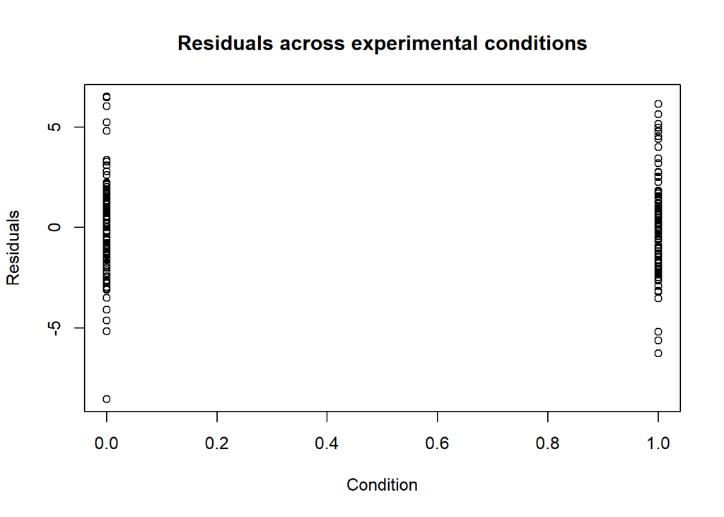

```r
plot(df$condition_num, residuals(model),
     xlab = 'Condition', ylab = 'Residuals',
     main = 'Residuals across experimental conditions')
```

That doesn’t look so bad. What about by party?

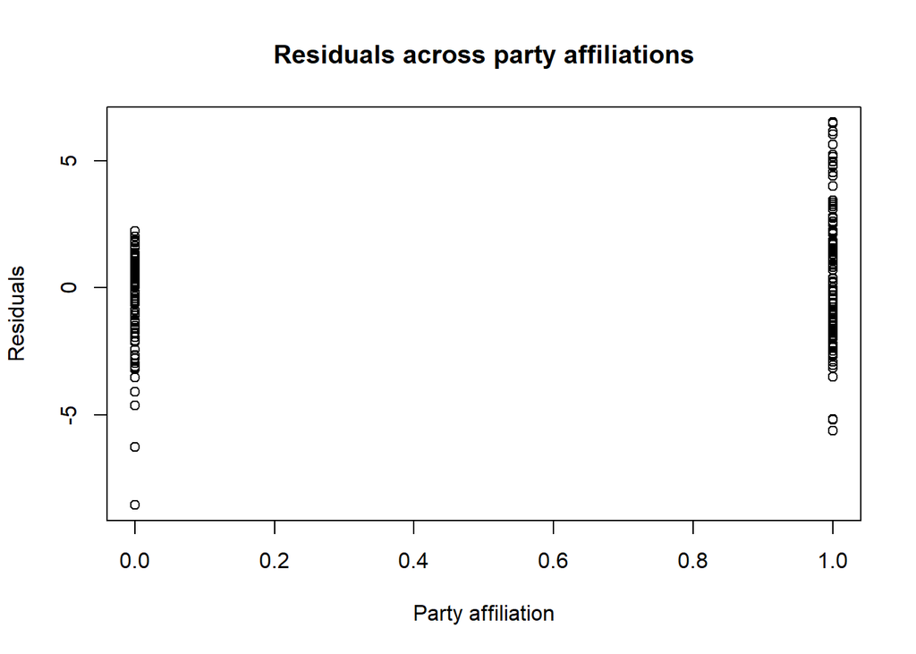

```r
plot(df$party_num, residuals(model),
     xlab = 'Party affiliation', ylab = 'Residuals',
     main = 'Residuals across party affiliations')
```

This is *maybe* a problem. Not necessarily that we see differences in direction here (which I think is consistent with a main effect of party affiliation), but that it looks like residuals are more tightly clustered for Democrats than for Republicans. Our model did a better job predicting democrats’ positions on protesters than Republicans.

What about by hmp?

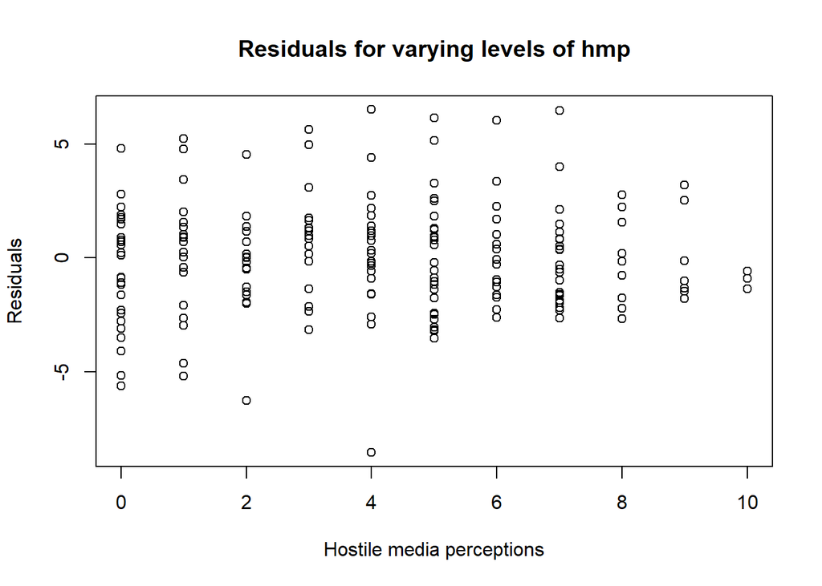

```r
plot(df$hmp, residuals(model),
     xlab = 'Hostile media perceptions', ylab = 'Residuals',
     main = 'Residuals for varying levels of hmp')
```

This might be the problem. We have less variance at the high end of hmp, probably because we have fewer observations.

So we have a (probably not egregious) violation of the heteroscedasticity assumption… maybe. It doesn’t seem like a huge deal to me… but might be worth mentioning to Doug.

### 5. Linearity

Finally, we want to test whether the relationships have a linear relationship with one another. I only know how to do this with component-residual plots, which don’t work for interactions. So I’ll just test a similar model with no interaction term – we won’t get a plot of the interaction term, but will get one of every predictor (which is what we need).

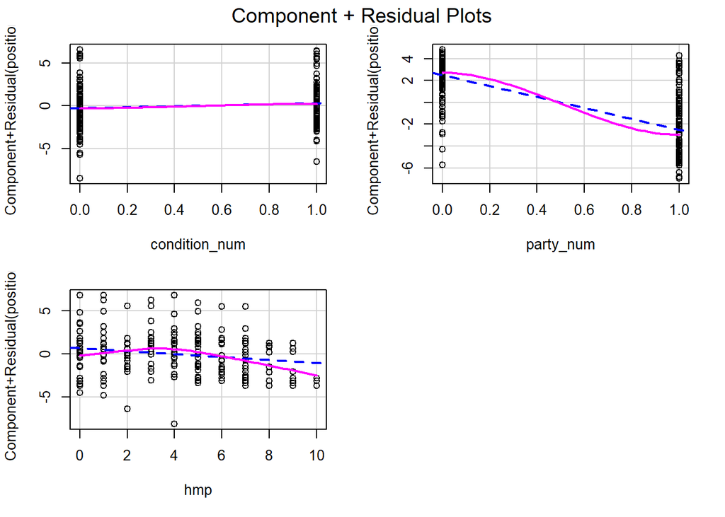

```r
model_noint <- lm(position ~ condition_num + party_num + hmp, df)
crPlots(model_noint)
```

This looks pretty good! Again, we see a little bit of misalignment with hmp… but I personally (and perhaps stupidly) don’t think it looks egregious.

## Parameter estimates!

Ok! So the data doesn’t perfectly meet our model assumptions… but my experience suggests it’s good enough. Let’s look at and interpret the parameters

```r
summary(model)
```

```
##
## Call:
## lm(formula = position ~ condition_num + party_num * hmp_C, data = df)
##
## Residuals:
##     Min      1Q  Median      3Q     Max
## -8.5612 -1.5948  0.2461  1.3063  6.5271
##
## Coefficients:
##                 Estimate Std. Error t value Pr(>|t|)
## (Intercept)      8.57632    0.27411  31.288  < 2e-16 ***
## condition_num    0.45138    0.29774   1.516   0.1308
## party_num       -5.13612    0.31438 -16.337  < 2e-16 ***
## hmp_C            0.19790    0.08924   2.218   0.0275 *
## party_num:hmp_C -0.62545    0.11532  -5.423 1.41e-07 ***
## ---
## Signif. codes:  0 '***' 0.001 '**' 0.01 '*' 0.05 '.' 0.1 ' ' 1
##
## Residual standard error: 2.329 on 243 degrees of freedom
## Multiple R-squared:  0.6034, Adjusted R-squared:  0.5968
## F-statistic: 92.41 on 4 and 243 DF,  p-value: < 2.2e-16
```

1. Intercept — for a participant with in the Low_W condition who is from the Democratic party and has an average level of hmp, we expect a position score of 8.576
2. condition_num — Controlling for all other parameters, the expected difference in position scores across the conditions is just 0.451. This is not large enough to be statistically significant.
3. party_num — Controlling for all other parameters, the expected difference in position scores across the parties is 5.136 — Republican scores are on average 5.14 points lower than Democrats’ scores! This is obviously significant.
4. hmp_C — Controlling for all other parameters, a participant’s expected position increases by 0.198 points for every one-unit increase in hostile media perceptions. (Technically, this is for Democrats in the low_W condition).
5. party_num:hmp_C — Controlling for all other parameters, the effect of hmp on position is affected by party. Democrats’ expected position climbs 0.198 points for each unit of hostile media perception, but Republicans’ expected positions drop by 0.427 points for each increase in hmp. This is highly significant.